# Risk Factor Analysis

## Outcome Variable

**Outcome Variable:** ever_swasted

## Predictor Variables

**Intervention Variable:** hfoodsec

**Adjustment Set:**

unadjusted

## Stratifying Variables

The analysis was stratified on these variable(s):

- agecat
- studyid
- country

## Data Summary

| agecat | studyid | country | hfoodsec | ever_swasted | n_cell | n |
| --- | --- | --- | --- | --- | --- | --- |
| 0-24 months | ki0047075b-MAL-ED | BANGLADESH | Food Secure | 0 | 146 | 194 |
| 0-24 months | ki0047075b-MAL-ED | BANGLADESH | Food Secure | 1 | 15 | 194 |
| 0-24 months | ki0047075b-MAL-ED | BANGLADESH | Mildly Food Insecure | 0 | 4 | 194 |
| 0-24 months | ki0047075b-MAL-ED | BANGLADESH | Mildly Food Insecure | 1 | 0 | 194 |
| 0-24 months | ki0047075b-MAL-ED | BANGLADESH | Food Insecure | 0 | 26 | 194 |
| 0-24 months | ki0047075b-MAL-ED | BANGLADESH | Food Insecure | 1 | 3 | 194 |
| 0-24 months | ki0047075b-MAL-ED | BRAZIL | Food Secure | 0 | 3 | 129 |
| 0-24 months | ki0047075b-MAL-ED | BRAZIL | Food Secure | 1 | 0 | 129 |
| 0-24 months | ki0047075b-MAL-ED | BRAZIL | Mildly Food Insecure | 0 | 11 | 129 |
| 0-24 months | ki0047075b-MAL-ED | BRAZIL | Mildly Food Insecure | 1 | 0 | 129 |
| 0-24 months | ki0047075b-MAL-ED | BRAZIL | Food Insecure | 0 | 113 | 129 |
| 0-24 months | ki0047075b-MAL-ED | BRAZIL | Food Insecure | 1 | 2 | 129 |
| 0-24 months | ki0047075b-MAL-ED | INDIA | Food Secure | 0 | 170 | 212 |
| 0-24 months | ki0047075b-MAL-ED | INDIA | Food Secure | 1 | 20 | 212 |
| 0-24 months | ki0047075b-MAL-ED | INDIA | Mildly Food Insecure | 0 | 3 | 212 |
| 0-24 months | ki0047075b-MAL-ED | INDIA | Mildly Food Insecure | 1 | 2 | 212 |
| 0-24 months | ki0047075b-MAL-ED | INDIA | Food Insecure | 0 | 16 | 212 |
| 0-24 months | ki0047075b-MAL-ED | INDIA | Food Insecure | 1 | 1 | 212 |
| 0-24 months | ki0047075b-MAL-ED | NEPAL | Food Secure | 0 | 92 | 128 |
| 0-24 months | ki0047075b-MAL-ED | NEPAL | Food Secure | 1 | 2 | 128 |
| 0-24 months | ki0047075b-MAL-ED | NEPAL | Mildly Food Insecure | 0 | 14 | 128 |
| 0-24 months | ki0047075b-MAL-ED | NEPAL | Mildly Food Insecure | 1 | 1 | 128 |
| 0-24 months | ki0047075b-MAL-ED | NEPAL | Food Insecure | 0 | 18 | 128 |
| 0-24 months | ki0047075b-MAL-ED | NEPAL | Food Insecure | 1 | 1 | 128 |
| 0-24 months | ki0047075b-MAL-ED | PERU | Food Secure | 0 | 26 | 113 |
| 0-24 months | ki0047075b-MAL-ED | PERU | Food Secure | 1 | 1 | 113 |
| 0-24 months | ki0047075b-MAL-ED | PERU | Mildly Food Insecure | 0 | 29 | 113 |
| 0-24 months | ki0047075b-MAL-ED | PERU | Mildly Food Insecure | 1 | 0 | 113 |
| 0-24 months | ki0047075b-MAL-ED | PERU | Food Insecure | 0 | 55 | 113 |
| 0-24 months | ki0047075b-MAL-ED | PERU | Food Insecure | 1 | 2 | 113 |

[output cut: 168 more lines]

The following strata were considered:

- agecat: 0-24 months, studyid: ki0047075b-MAL-ED, country: BANGLADESH
- agecat: 0-24 months, studyid: ki0047075b-MAL-ED, country: BRAZIL
- agecat: 0-24 months, studyid: ki0047075b-MAL-ED, country: INDIA
- agecat: 0-24 months, studyid: ki0047075b-MAL-ED, country: NEPAL
- agecat: 0-24 months, studyid: ki0047075b-MAL-ED, country: PERU
- agecat: 0-24 months, studyid: ki0047075b-MAL-ED, country: SOUTH AFRICA
- agecat: 0-24 months, studyid: ki1017093-NIH-Birth, country: BANGLADESH
- agecat: 0-24 months, studyid: ki1017093c-NIH-Crypto, country: BANGLADESH
- agecat: 0-24 months, studyid: ki1113344-GMS-Nepal, country: NEPAL
- agecat: 0-24 months, studyid: kiGH5241-JiVitA-3, country: BANGLADESH
- agecat: 0-24 months, studyid: kiGH5241-JiVitA-4, country: BANGLADESH
- agecat: 0-6 months, studyid: ki0047075b-MAL-ED, country: BANGLADESH
- agecat: 0-6 months, studyid: ki0047075b-MAL-ED, country: BRAZIL
- agecat: 0-6 months, studyid: ki0047075b-MAL-ED, country: INDIA
- agecat: 0-6 months, studyid: ki0047075b-MAL-ED, country: NEPAL
- agecat: 0-6 months, studyid: ki0047075b-MAL-ED, country: PERU
- agecat: 0-6 months, studyid: ki0047075b-MAL-ED, country: SOUTH AFRICA
- agecat: 0-6 months, studyid: ki1017093-NIH-Birth, country: BANGLADESH
- agecat: 0-6 months, studyid: ki1017093c-NIH-Crypto, country: BANGLADESH
- agecat: 0-6 months, studyid: ki1113344-GMS-Nepal, country: NEPAL
- agecat: 0-6 months, studyid: kiGH5241-JiVitA-3, country: BANGLADESH
- agecat: 0-6 months, studyid: kiGH5241-JiVitA-4, country: BANGLADESH
- agecat: 6-24 months, studyid: ki0047075b-MAL-ED, country: BANGLADESH
- agecat: 6-24 months, studyid: ki0047075b-MAL-ED, country: BRAZIL
- agecat: 6-24 months, studyid: ki0047075b-MAL-ED, country: INDIA
- agecat: 6-24 months, studyid: ki0047075b-MAL-ED, country: NEPAL
- agecat: 6-24 months, studyid: ki0047075b-MAL-ED, country: PERU
- agecat: 6-24 months, studyid: ki0047075b-MAL-ED, country: SOUTH AFRICA
- agecat: 6-24 months, studyid: ki1017093-NIH-Birth, country: BANGLADESH
- agecat: 6-24 months, studyid: ki1017093c-NIH-Crypto, country: BANGLADESH
- agecat: 6-24 months, studyid: ki1113344-GMS-Nepal, country: NEPAL
- agecat: 6-24 months, studyid: kiGH5241-JiVitA-3, country: BANGLADESH
- agecat: 6-24 months, studyid: kiGH5241-JiVitA-4, country: BANGLADESH

### Dropped Strata

Some strata were dropped due to rare outcomes:

- agecat: 0-24 months, studyid: ki0047075b-MAL-ED, country: BANGLADESH
- agecat: 0-24 months, studyid: ki0047075b-MAL-ED, country: BRAZIL
- agecat: 0-24 months, studyid: ki0047075b-MAL-ED, country: INDIA
- agecat: 0-24 months, studyid: ki0047075b-MAL-ED, country: NEPAL
- agecat: 0-24 months, studyid: ki0047075b-MAL-ED, country: PERU
- agecat: 0-24 months, studyid: ki0047075b-MAL-ED, country: SOUTH AFRICA
- agecat: 0-6 months, studyid: ki0047075b-MAL-ED, country: BANGLADESH
- agecat: 0-6 months, studyid: ki0047075b-MAL-ED, country: BRAZIL
- agecat: 0-6 months, studyid: ki0047075b-MAL-ED, country: INDIA
- agecat: 0-6 months, studyid: ki0047075b-MAL-ED, country: NEPAL
- agecat: 0-6 months, studyid: ki0047075b-MAL-ED, country: PERU
- agecat: 0-6 months, studyid: ki0047075b-MAL-ED, country: SOUTH AFRICA
- agecat: 0-6 months, studyid: ki1017093c-NIH-Crypto, country: BANGLADESH
- agecat: 6-24 months, studyid: ki0047075b-MAL-ED, country: BANGLADESH
- agecat: 6-24 months, studyid: ki0047075b-MAL-ED, country: BRAZIL
- agecat: 6-24 months, studyid: ki0047075b-MAL-ED, country: INDIA
- agecat: 6-24 months, studyid: ki0047075b-MAL-ED, country: NEPAL
- agecat: 6-24 months, studyid: ki0047075b-MAL-ED, country: PERU
- agecat: 6-24 months, studyid: ki0047075b-MAL-ED, country: SOUTH AFRICA
- agecat: 6-24 months, studyid: ki1017093-NIH-Birth, country: BANGLADESH
- agecat: 6-24 months, studyid: ki1017093c-NIH-Crypto, country: BANGLADESH

## Methods Detail

We’re interested in the causal parameters $E[Y_a]$ for all values of $a \in \mathcal{A}$. These parameters represent the mean outcome if, possibly contrary to fact, we intervened to set all units to have $A=a$. Under the randomization and positivity assumptions, these are identified by the statistical parameters $\psi_a=E_W[E_{Y|A,W}(Y|A=a,W)]$. In addition, we’re interested in the mean of $Y$, $E[Y]$ under no intervention (the observed mean). We will estimate these parameters by using SuperLearner to fit the relevant likelihood factors – $E_{Y|A,W}(Y|A=a,W)$ and $p(A=a|W)$, and then updating our likelihood fit using a joint TMLE.

For unadjusted analyses ($W=\{\}$), initial likelihoods were estimated using Lrnr_glm to estimate the simple $E(Y|A)$ and Lrnr_mean to estimate $p(A)$. For adjusted analyses, a small library containing Lrnr_glmnet, Lrnr_xgboost, and Lrnr_mean was used.

Having estimated these parameters, we will then use the delta method to estimate relative risks and attributable risks relative to a prespecified baseline level of $A$.

# Results Detail

## Results Plots

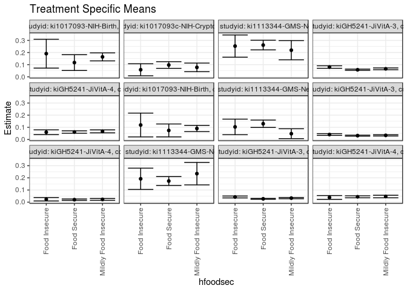

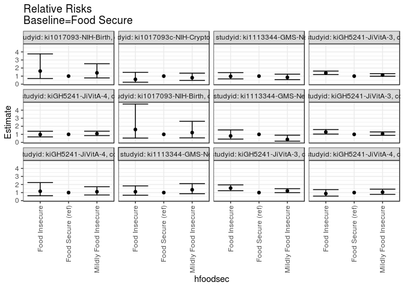

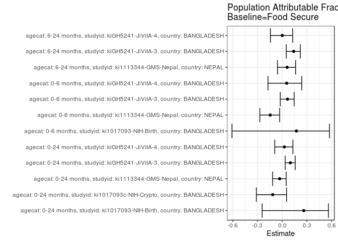

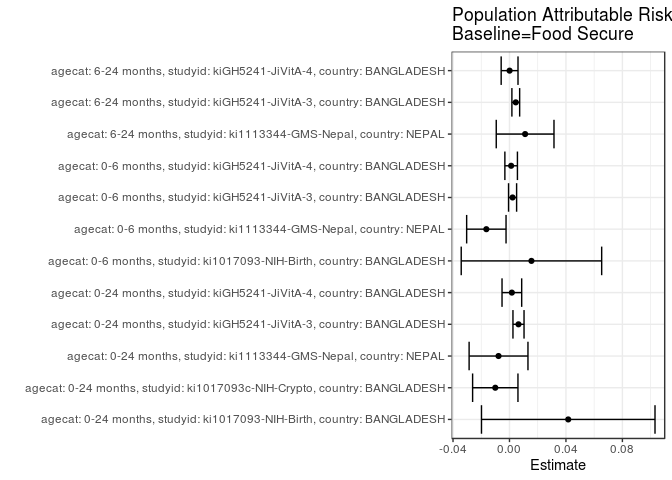

## Results Table

### Parameter: TSM

| agecat | studyid | country | intervention_level | baseline_level | estimate | ci_lower | ci_upper |
| --- | --- | --- | --- | --- | --- | --- | --- |
| 0-24 months | ki1017093-NIH-Birth | BANGLADESH | Food Secure | NA | 0.1170213 | 0.0519874 | 0.1820552 |
| 0-24 months | ki1017093-NIH-Birth | BANGLADESH | Mildly Food Insecure | NA | 0.1639344 | 0.1310612 | 0.1968076 |
| 0-24 months | ki1017093-NIH-Birth | BANGLADESH | Food Insecure | NA | 0.1904762 | 0.0716241 | 0.3093283 |
| 0-24 months | ki1017093c-NIH-Crypto | BANGLADESH | Food Secure | NA | 0.0971302 | 0.0698420 | 0.1244185 |
| 0-24 months | ki1017093c-NIH-Crypto | BANGLADESH | Mildly Food Insecure | NA | 0.0776256 | 0.0421631 | 0.1130880 |
| 0-24 months | ki1017093c-NIH-Crypto | BANGLADESH | Food Insecure | NA | 0.0581395 | 0.0086499 | 0.1076292 |
| 0-24 months | ki1113344-GMS-Nepal | NEPAL | Food Secure | NA | 0.2611465 | 0.2214468 | 0.3008461 |
| 0-24 months | ki1113344-GMS-Nepal | NEPAL | Mildly Food Insecure | NA | 0.2190476 | 0.1398772 | 0.2982180 |
| 0-24 months | ki1113344-GMS-Nepal | NEPAL | Food Insecure | NA | 0.2528736 | 0.1614696 | 0.3442775 |
| 0-24 months | kiGH5241-JiVitA-3 | BANGLADESH | Food Secure | NA | 0.0578427 | 0.0523711 | 0.0633143 |
| 0-24 months | kiGH5241-JiVitA-3 | BANGLADESH | Mildly Food Insecure | NA | 0.0656985 | 0.0585006 | 0.0728963 |
| 0-24 months | kiGH5241-JiVitA-3 | BANGLADESH | Food Insecure | NA | 0.0804836 | 0.0702072 | 0.0907600 |
| 0-24 months | kiGH5241-JiVitA-4 | BANGLADESH | Food Secure | NA | 0.0614769 | 0.0517693 | 0.0711845 |
| 0-24 months | kiGH5241-JiVitA-4 | BANGLADESH | Mildly Food Insecure | NA | 0.0667351 | 0.0545972 | 0.0788730 |
| 0-24 months | kiGH5241-JiVitA-4 | BANGLADESH | Food Insecure | NA | 0.0598291 | 0.0403152 | 0.0793429 |
| 0-6 months | ki1017093-NIH-Birth | BANGLADESH | Food Secure | NA | 0.0744681 | 0.0213534 | 0.1275827 |
| 0-6 months | ki1017093-NIH-Birth | BANGLADESH | Mildly Food Insecure | NA | 0.0905350 | 0.0650032 | 0.1160667 |
| 0-6 months | ki1017093-NIH-Birth | BANGLADESH | Food Insecure | NA | 0.1190476 | 0.0210288 | 0.2170664 |
| 0-6 months | ki1113344-GMS-Nepal | NEPAL | Food Secure | NA | 0.1295117 | 0.0991657 | 0.1598577 |
| 0-6 months | ki1113344-GMS-Nepal | NEPAL | Mildly Food Insecure | NA | 0.0476190 | 0.0068550 | 0.0883831 |
| 0-6 months | ki1113344-GMS-Nepal | NEPAL | Food Insecure | NA | 0.1034483 | 0.0394062 | 0.1674904 |
| 0-6 months | kiGH5241-JiVitA-3 | BANGLADESH | Food Secure | NA | 0.0316543 | 0.0275144 | 0.0357943 |
| 0-6 months | kiGH5241-JiVitA-3 | BANGLADESH | Mildly Food Insecure | NA | 0.0337626 | 0.0283839 | 0.0391413 |
| 0-6 months | kiGH5241-JiVitA-3 | BANGLADESH | Food Insecure | NA | 0.0406391 | 0.0334829 | 0.0477953 |
| 0-6 months | kiGH5241-JiVitA-4 | BANGLADESH | Food Secure | NA | 0.0205586 | 0.0146368 | 0.0264803 |
| 0-6 months | kiGH5241-JiVitA-4 | BANGLADESH | Mildly Food Insecure | NA | 0.0226269 | 0.0150128 | 0.0302411 |
| 0-6 months | kiGH5241-JiVitA-4 | BANGLADESH | Food Insecure | NA | 0.0239163 | 0.0099284 | 0.0379042 |
| 6-24 months | ki1113344-GMS-Nepal | NEPAL | Food Secure | NA | 0.1739130 | 0.1373699 | 0.2104562 |
| 6-24 months | ki1113344-GMS-Nepal | NEPAL | Mildly Food Insecure | NA | 0.2345679 | 0.1422103 | 0.3269255 |
| 6-24 months | ki1113344-GMS-Nepal | NEPAL | Food Insecure | NA | 0.1923077 | 0.1047687 | 0.2798467 |
| 6-24 months | kiGH5241-JiVitA-3 | BANGLADESH | Food Secure | NA | 0.0274528 | 0.0237575 | 0.0311481 |
| 6-24 months | kiGH5241-JiVitA-3 | BANGLADESH | Mildly Food Insecure | NA | 0.0332579 | 0.0280240 | 0.0384917 |
| 6-24 months | kiGH5241-JiVitA-3 | BANGLADESH | Food Insecure | NA | 0.0426723 | 0.0348517 | 0.0504928 |
| 6-24 months | kiGH5241-JiVitA-4 | BANGLADESH | Food Secure | NA | 0.0441123 | 0.0357805 | 0.0524441 |
| 6-24 months | kiGH5241-JiVitA-4 | BANGLADESH | Mildly Food Insecure | NA | 0.0462963 | 0.0357221 | 0.0568705 |
| 6-24 months | kiGH5241-JiVitA-4 | BANGLADESH | Food Insecure | NA | 0.0386266 | 0.0228939 | 0.0543593 |

### Parameter: E(Y)

| agecat | studyid | country | intervention_level | baseline_level | estimate | ci_lower | ci_upper |
| --- | --- | --- | --- | --- | --- | --- | --- |
| 0-24 months | ki1017093-NIH-Birth | BANGLADESH | NA | NA | 0.1586538 | 0.1299648 | 0.1873429 |
| 0-24 months | ki1017093c-NIH-Crypto | BANGLADESH | NA | NA | 0.0870712 | 0.0669870 | 0.1071555 |
| 0-24 months | ki1113344-GMS-Nepal | NEPAL | NA | NA | 0.2533937 | 0.2202605 | 0.2865268 |
| 0-24 months | kiGH5241-JiVitA-3 | BANGLADESH | NA | NA | 0.0642302 | 0.0601218 | 0.0683386 |
| 0-24 months | kiGH5241-JiVitA-4 | BANGLADESH | NA | NA | 0.0631598 | 0.0562585 | 0.0700612 |
| 0-6 months | ki1017093-NIH-Birth | BANGLADESH | NA | NA | 0.0900322 | 0.0675202 | 0.1125442 |
| 0-6 months | ki1113344-GMS-Nepal | NEPAL | NA | NA | 0.1131222 | 0.0889940 | 0.1372504 |
| 0-6 months | kiGH5241-JiVitA-3 | BANGLADESH | NA | NA | 0.0338522 | 0.0307634 | 0.0369410 |
| 0-6 months | kiGH5241-JiVitA-4 | BANGLADESH | NA | NA | 0.0217434 | 0.0173381 | 0.0261487 |
| 6-24 months | ki1113344-GMS-Nepal | NEPAL | NA | NA | 0.1849913 | 0.1531708 | 0.2168118 |
| 6-24 months | kiGH5241-JiVitA-3 | BANGLADESH | NA | NA | 0.0319118 | 0.0290313 | 0.0347923 |
| 6-24 months | kiGH5241-JiVitA-4 | BANGLADESH | NA | NA | 0.0441886 | 0.0382741 | 0.0501032 |

### Parameter: RR

| agecat | studyid | country | intervention_level | baseline_level | estimate | ci_lower | ci_upper |
| --- | --- | --- | --- | --- | --- | --- | --- |
| 0-24 months | ki1017093-NIH-Birth | BANGLADESH | Food Secure | Food Secure | 1.0000000 | 1.0000000 | 1.0000000 |
| 0-24 months | ki1017093-NIH-Birth | BANGLADESH | Mildly Food Insecure | Food Secure | 1.4008942 | 0.7759210 | 2.5292582 |
| 0-24 months | ki1017093-NIH-Birth | BANGLADESH | Food Insecure | Food Secure | 1.6277056 | 0.7058100 | 3.7537375 |
| 0-24 months | ki1017093c-NIH-Crypto | BANGLADESH | Food Secure | Food Secure | 1.0000000 | 1.0000000 | 1.0000000 |
| 0-24 months | ki1017093c-NIH-Crypto | BANGLADESH | Mildly Food Insecure | Food Secure | 0.7991905 | 0.4674468 | 1.3663705 |
| 0-24 months | ki1017093c-NIH-Crypto | BANGLADESH | Food Insecure | Food Secure | 0.5985729 | 0.2442425 | 1.4669421 |
| 0-24 months | ki1113344-GMS-Nepal | NEPAL | Food Secure | Food Secure | 1.0000000 | 1.0000000 | 1.0000000 |
| 0-24 months | ki1113344-GMS-Nepal | NEPAL | Mildly Food Insecure | Food Secure | 0.8387921 | 0.5667190 | 1.2414834 |
| 0-24 months | ki1113344-GMS-Nepal | NEPAL | Food Insecure | Food Secure | 0.9683207 | 0.6542145 | 1.4332378 |
| 0-24 months | kiGH5241-JiVitA-3 | BANGLADESH | Food Secure | Food Secure | 1.0000000 | 1.0000000 | 1.0000000 |
| 0-24 months | kiGH5241-JiVitA-3 | BANGLADESH | Mildly Food Insecure | Food Secure | 1.1358131 | 0.9849922 | 1.3097274 |
| 0-24 months | kiGH5241-JiVitA-3 | BANGLADESH | Food Insecure | Food Secure | 1.3914221 | 1.1915924 | 1.6247632 |
| 0-24 months | kiGH5241-JiVitA-4 | BANGLADESH | Food Secure | Food Secure | 1.0000000 | 1.0000000 | 1.0000000 |
| 0-24 months | kiGH5241-JiVitA-4 | BANGLADESH | Mildly Food Insecure | Food Secure | 1.0855315 | 0.8470013 | 1.3912360 |
| 0-24 months | kiGH5241-JiVitA-4 | BANGLADESH | Food Insecure | Food Secure | 0.9731958 | 0.6825349 | 1.3876360 |
| 0-6 months | ki1017093-NIH-Birth | BANGLADESH | Food Secure | Food Secure | 1.0000000 | 1.0000000 | 1.0000000 |
| 0-6 months | ki1017093-NIH-Birth | BANGLADESH | Mildly Food Insecure | Food Secure | 1.2157554 | 0.5646124 | 2.6178337 |
| 0-6 months | ki1017093-NIH-Birth | BANGLADESH | Food Insecure | Food Secure | 1.5986395 | 0.5378468 | 4.7516283 |
| 0-6 months | ki1113344-GMS-Nepal | NEPAL | Food Secure | Food Secure | 1.0000000 | 1.0000000 | 1.0000000 |
| 0-6 months | ki1113344-GMS-Nepal | NEPAL | Mildly Food Insecure | Food Secure | 0.3676815 | 0.1513636 | 0.8931453 |
| 0-6 months | ki1113344-GMS-Nepal | NEPAL | Food Insecure | Food Secure | 0.7987564 | 0.4120415 | 1.5484160 |
| 0-6 months | kiGH5241-JiVitA-3 | BANGLADESH | Food Secure | Food Secure | 1.0000000 | 1.0000000 | 1.0000000 |
| 0-6 months | kiGH5241-JiVitA-3 | BANGLADESH | Mildly Food Insecure | Food Secure | 1.0666030 | 0.8752601 | 1.2997759 |
| 0-6 months | kiGH5241-JiVitA-3 | BANGLADESH | Food Insecure | Food Secure | 1.2838399 | 1.0335823 | 1.5946915 |
| 0-6 months | kiGH5241-JiVitA-4 | BANGLADESH | Food Secure | Food Secure | 1.0000000 | 1.0000000 | 1.0000000 |
| 0-6 months | kiGH5241-JiVitA-4 | BANGLADESH | Mildly Food Insecure | Food Secure | 1.1006081 | 0.7026943 | 1.7238481 |
| 0-6 months | kiGH5241-JiVitA-4 | BANGLADESH | Food Insecure | Food Secure | 1.1633246 | 0.6046574 | 2.2381667 |
| 6-24 months | ki1113344-GMS-Nepal | NEPAL | Food Secure | Food Secure | 1.0000000 | 1.0000000 | 1.0000000 |
| 6-24 months | ki1113344-GMS-Nepal | NEPAL | Mildly Food Insecure | Food Secure | 1.3487654 | 0.8632033 | 2.1074620 |
| 6-24 months | ki1113344-GMS-Nepal | NEPAL | Food Insecure | Food Secure | 1.1057692 | 0.6697719 | 1.8255851 |
| 6-24 months | kiGH5241-JiVitA-3 | BANGLADESH | Food Secure | Food Secure | 1.0000000 | 1.0000000 | 1.0000000 |
| 6-24 months | kiGH5241-JiVitA-3 | BANGLADESH | Mildly Food Insecure | Food Secure | 1.2114568 | 0.9908701 | 1.4811504 |
| 6-24 months | kiGH5241-JiVitA-3 | BANGLADESH | Food Insecure | Food Secure | 1.5543867 | 1.2387397 | 1.9504647 |
| 6-24 months | kiGH5241-JiVitA-4 | BANGLADESH | Food Secure | Food Secure | 1.0000000 | 1.0000000 | 1.0000000 |
| 6-24 months | kiGH5241-JiVitA-4 | BANGLADESH | Mildly Food Insecure | Food Secure | 1.0495103 | 0.7753959 | 1.4205283 |
| 6-24 months | kiGH5241-JiVitA-4 | BANGLADESH | Food Insecure | Food Secure | 0.8756429 | 0.5615095 | 1.3655164 |

### Parameter: PAR

| agecat | studyid | country | intervention_level | baseline_level | estimate | ci_lower | ci_upper |
| --- | --- | --- | --- | --- | --- | --- | --- |
| 0-24 months | ki1017093-NIH-Birth | BANGLADESH | Food Secure | NA | 0.0416326 | -0.0198347 | 0.1030999 |
| 0-24 months | ki1017093c-NIH-Crypto | BANGLADESH | Food Secure | NA | -0.0100590 | -0.0261209 | 0.0060029 |
| 0-24 months | ki1113344-GMS-Nepal | NEPAL | Food Secure | NA | -0.0077528 | -0.0285993 | 0.0130937 |
| 0-24 months | kiGH5241-JiVitA-3 | BANGLADESH | Food Secure | NA | 0.0063875 | 0.0024639 | 0.0103112 |
| 0-24 months | kiGH5241-JiVitA-4 | BANGLADESH | Food Secure | NA | 0.0016829 | -0.0052809 | 0.0086468 |
| 0-6 months | ki1017093-NIH-Birth | BANGLADESH | Food Secure | NA | 0.0155641 | -0.0341879 | 0.0653160 |
| 0-6 months | ki1113344-GMS-Nepal | NEPAL | Food Secure | NA | -0.0163895 | -0.0303412 | -0.0024378 |
| 0-6 months | kiGH5241-JiVitA-3 | BANGLADESH | Food Secure | NA | 0.0021979 | -0.0006556 | 0.0050513 |
| 0-6 months | kiGH5241-JiVitA-4 | BANGLADESH | Food Secure | NA | 0.0011849 | -0.0032636 | 0.0056333 |
| 6-24 months | ki1113344-GMS-Nepal | NEPAL | Food Secure | NA | 0.0110782 | -0.0093730 | 0.0315295 |
| 6-24 months | kiGH5241-JiVitA-3 | BANGLADESH | Food Secure | NA | 0.0044590 | 0.0017114 | 0.0072067 |
| 6-24 months | kiGH5241-JiVitA-4 | BANGLADESH | Food Secure | NA | 0.0000764 | -0.0058874 | 0.0060401 |

### Parameter: PAF

| agecat | studyid | country | intervention_level | baseline_level | estimate | ci_lower | ci_upper |
| --- | --- | --- | --- | --- | --- | --- | --- |
| 0-24 months | ki1017093-NIH-Birth | BANGLADESH | Food Secure | NA | 0.2624113 | -0.2436437 | 0.5625459 |
| 0-24 months | ki1017093c-NIH-Crypto | BANGLADESH | Food Secure | NA | -0.1155261 | -0.3143298 | 0.0532068 |
| 0-24 months | ki1113344-GMS-Nepal | NEPAL | Food Secure | NA | -0.0305960 | -0.1162063 | 0.0484482 |
| 0-24 months | kiGH5241-JiVitA-3 | BANGLADESH | Food Secure | NA | 0.0994474 | 0.0363797 | 0.1583875 |
| 0-24 months | kiGH5241-JiVitA-4 | BANGLADESH | Food Secure | NA | 0.0266458 | -0.0900786 | 0.1308715 |
| 0-6 months | ki1017093-NIH-Birth | BANGLADESH | Food Secure | NA | 0.1728723 | -0.6105727 | 0.5752193 |
| 0-6 months | ki1113344-GMS-Nepal | NEPAL | Food Secure | NA | -0.1448832 | -0.2720211 | -0.0304527 |
| 0-6 months | kiGH5241-JiVitA-3 | BANGLADESH | Food Secure | NA | 0.0649253 | -0.0233110 | 0.1455533 |
| 0-6 months | kiGH5241-JiVitA-4 | BANGLADESH | Food Secure | NA | 0.0544926 | -0.1728407 | 0.2377615 |
| 6-24 months | ki1113344-GMS-Nepal | NEPAL | Food Secure | NA | 0.0598852 | -0.0571203 | 0.1639401 |
| 6-24 months | kiGH5241-JiVitA-3 | BANGLADESH | Food Secure | NA | 0.1397292 | 0.0500844 | 0.2209141 |
| 6-24 months | kiGH5241-JiVitA-4 | BANGLADESH | Food Secure | NA | 0.0017279 | -0.1427780 | 0.1279608 |